# Independent Means and Medians

## Introduction

- In the last module, we reviewed statistical inference for one sample.
- In this module, we will focus on tests for two samples.
  - Two-sample independent means ($\mu_1-\mu_2$)
  - Two-sample dependent means ($\mu_d$)
  - Two-sample proportions ($\pi_1-\pi_2$)
  - Two-sample variances ($\sigma^2_1/\sigma^2_2$)
- In this lecture: two-sample independent means ($\mu_1-\mu_2$)

## `R` Setup

```r
library(tidyverse)
library(ssstats)
```

- Recall our Zootopia data,

```r
zootopia <- read_csv("https://raw.githubusercontent.com/samanthaseals/SDSI/refs/heads/main/files/data/lectures/1-zootopia.csv")
```

| resident_name | department | district | academy_status | academy_exam_score | sleep_hours | hustle_earnings | district_temp_f |
| --- | --- | --- | --- | --- | --- | --- | --- |
| Sable Jones | Desk | Rainforest District | Fail | 65 | 5.5 | 14.72 | 72.2 |
| Kevin Frostwhisker | Patrol | Downtown | Fail | 69 | 7.4 | 45.66 | 66.2 |
| Jasper Duskrunner | Patrol | Sahara Square | Pass | 79 | 8.7 | 30.91 | 89.8 |

## Confidence Interval for $\mu_1-\mu_2$

- (1–$\alpha$)100% CI for a population mean, $\mu_1-\mu_2$

$$(\bar{y}_1 - \bar{y}_2) \pm t_{\alpha/2} \sqrt{\frac{s_1^2 }{n_1} + \frac{s_2^2}{n_2}}$$

- where
  - $(\bar{x}_1-\bar{x}_2)$ is the point estimate for $\mu_1-\mu_2$
    - $\bar{x}_i$ is the sample mean for group $i$
  - $t_{\alpha/2}$ has $\min(n_1-1, n_2-1)$ degrees of freedom
  - $s_i^2$ is the sample variance for group $i$
  - $n_i$ is the sample size of group $i$

## Hypothesis Test for $\mu_1-\mu_2$

**Hypotheses**

**Two-Tailed**

$H_0: \mu_1-\mu_2 = \mu_0$

$H_1: \mu_1 - \mu_2 \ne \mu_0$

**Left-Tailed**

$H_0: \mu_1-\mu_2 \ge \mu_0$

$H_1: \mu_1-\mu_2 < \mu_0$

**Right-Tailed**

$H_0: \mu_1-\mu_2 \le \mu_0$

$H_1: \mu_1-\mu_2 > \mu_0$

- $\mu_i$ is the population mean for group $i$,
- $\mu_0$ is the hypothesized difference between the groups

## Hypothesis Test for $\mu_1-\mu_2$

**Test Statistic:**

$$t_0 = \frac{(\bar{x}_1-\bar{x}_2)-\mu_0}{{\sqrt{\frac{s_1^2}{n_1} + \frac{s^2_2}{n_2}}}} \sim t_{\text{df}}$$

- where
  - $\bar{x}_i$ is the mean for group $i$
  - $\mu_0$ is the hypothesized difference
  - $s_i^2$ is the sample variance for group $i$
  - $n_i$ is the sample size of group $i$
  - $\text{df} = \text{min}(n_1-1, n_2-1)$

## Statistical Inference on Two Means (`R`)

- We will use the `independent_means` function from `library(ssstats)` to perform statistical inference.
- Generic syntax:

```r
dataset_name |> independent_means(
  outcome = outcome_variable,
  grouping = grouping_variable,
  alternative = "two" | "less" | "greater",
  mu = hypothesized_difference,
  alpha = alpha_level
  )
```

**1**

Pipes your dataset into `independent_means()`.

**2**

`outcome`: the continuous variable you want to compare between the two groups.

**3**

`grouping`: the categorical variable that splits your data into the two groups being compared.

**4**

`alternative`: the direction of the test; default is `two`.

**5**

`mu`: the hypothesized difference between the two groups under $H_0$; default is 0.

**6**

`alpha`: the significance level; default is 0.05.

## Example 1

- Okonkwo pings you on your first morning back from vacation: “Patrol runs early shifts while Desk runs later ones and I keep hearing officers gripe about who’s more rested. Tell me if there’s actually a difference in how much sleep our two groups are getting.”
- We will use the `zootopia` dataset to answer the following question:
  - Is there a difference in average nightly sleep between Patrol and Desk officers?
- First, we need to describe the data.
  - We start with point and interval estimates.
- Then, we will perform a hypothesis test to answer the question.

## Example 1

- Point and interval estimates:

```r
zootopia |> independent_means(outcome = sleep_hours,
                              grouping = department)
```

```
Independent means (Welch's t-test)

x̅[Desk] = 6.2667
x̅[Patrol] = 7.1444
Point estimate: x̅[Desk] − x̅[Patrol] = -0.8777

95% CI for μ[Desk] − μ[Patrol]: (-1.9269, 0.1713)

Hypotheses:
H₀: μ[Desk] − μ[Patrol] = 0
H₁: μ[Desk] − μ[Patrol] ≠ 0
Test statistic: t(21.52) = -1.737
p-value: 0.097
Conclusion: Fail to reject the null hypothesis (p = 0.097 ≥ α = 0.050)
```

## Example 1

- Then, we will perform a hypothesis test to answer the question.
  - Is there a difference in average nightly sleep between Patrol and Desk officers?
- How do we translate this into hypotheses?
  - $H_0: \mu_{\text{Patrol}} = \mu_{\text{Desk}}$
  - $H_1: \mu_{\text{Patrol}} \ne \mu_{\text{Desk}}$
- For the `independent_means()` function, we will set
  - `mu = 0`
  - `alternative = "two"`.

## Example 1

- Is there a difference in average nightly sleep between Patrol and Desk officers?

```r
zootopia |> independent_means(outcome = sleep_hours,
                              grouping = department,
                              mu = 0,
                              alternative = "two")
```

```
Independent means (Welch's t-test)

x̅[Desk] = 6.2667
x̅[Patrol] = 7.1444
Point estimate: x̅[Desk] − x̅[Patrol] = -0.8777

95% CI for μ[Desk] − μ[Patrol]: (-1.9269, 0.1713)

Hypotheses:
H₀: μ[Desk] − μ[Patrol] = 0
H₁: μ[Desk] − μ[Patrol] ≠ 0
Test statistic: t(21.52) = -1.737
p-value: 0.097
Conclusion: Fail to reject the null hypothesis (p = 0.097 ≥ α = 0.050)
```

## Example 1

- **Hypotheses**
  - $H_0: \mu_{\text{Desk}} = \mu_{\text{Patrol}}$
  - $H_1: \mu_{\text{Desk}} \ne \mu_{\text{Patrol}}$
- **Test Statistic and *p*-Value**
  - $t_0 = -1.737$
  - $p = 0.097$
- **Rejection Region**
  - Reject $H_0$ if $p < \alpha$; $\alpha = 0.05$
- **Conclusion and Interpretation**
  - Fail to reject $H_0$. There is not sufficient evidence to suggest that average sleep differs between Patrol and Desk officers.

## Example 2

- Okonkwo’s back with another one: “Word around the precinct is that Patrol officers have more access to the public, so it’s naturally easier to run their side hustles. Let’s see what the data says – do Patrol officers earn more than Desk officers?”
- We will use the `zootopia` dataset to answer the following question:
  - Do patrol officers earn more than desk officers?
- First, we need to describe the data.
  - We start with point and interval estimates.
- Then, we will perform a hypothesis test to answer the question.

## Example 2

- Point and interval estimates:

```r
zootopia |> independent_means(outcome = hustle_earnings,
                              grouping = department)
```

```
Independent means (Welch's t-test)

x̅[Desk] = 31.6483
x̅[Patrol] = 40.0883
Point estimate: x̅[Desk] − x̅[Patrol] = -8.44

95% CI for μ[Desk] − μ[Patrol]: (-27.8211, 10.9411)

Hypotheses:
H₀: μ[Desk] − μ[Patrol] = 0
H₁: μ[Desk] − μ[Patrol] ≠ 0
Test statistic: t(17.45) = -0.917
p-value: 0.372
Conclusion: Fail to reject the null hypothesis (p = 0.372 ≥ α = 0.050)
```

## Example 2

- Do patrol officers earn more than desk officers?

```r
zootopia |> independent_means(outcome = hustle_earnings,
                              grouping = department,
                              mu = 0,
                              alternative = "less")
```

```
Independent means (Welch's t-test)

x̅[Desk] = 31.6483
x̅[Patrol] = 40.0883
Point estimate: x̅[Desk] − x̅[Patrol] = -8.44

95% CI for μ[Desk] − μ[Patrol]: (-27.8211, 10.9411)

Hypotheses:
H₀: μ[Desk] − μ[Patrol] ≥ 0
H₁: μ[Desk] − μ[Patrol] < 0
Test statistic: t(17.45) = -0.917
p-value: 0.186
Conclusion: Fail to reject the null hypothesis (p = 0.186 ≥ α = 0.050)
```

## Example 2

- **Hypotheses**
  - $H_0: \mu_{\text{Desk}} \ge \mu_{\text{Patrol}}$
  - $H_1: \mu_{\text{Desk}} < \mu_{\text{Patrol}}$
- **Test Statistic and *p*-Value**
  - $t_0 = -0.917$
  - $p = 0.186$
- **Rejection Region**
  - Reject $H_0$ if $p < \alpha$; $\alpha = 0.05$
- **Conclusion and Interpretation**
  - Fail to reject $H_0$. There is not sufficient evidence to suggest that patrol officers earn more in side hustles than desk officers.

## Assumption on Two-Sample *t*

- We assume that the data has an approximate mound-shaped and symmetric distribution.

$$y_{11}, y_{12}, \ldots, y_{1n_1} \sim N(\mu_1, \sigma_1^2)$$
$$y_{21}, y_{22}, \ldots, y_{2n_2} \sim N(\mu_2, \sigma_2^2)$$

- We will use a quantile-quantile plot (Q-Q plot) to check the assumption of normality.
  - We will also eyeball a histogram to further check the assumption of normality.

## Checking Normality (`R`)

- We will use the `independent_qq()` function from `library(ssstats)` to assess normality.

```r
dataset_name |> independent_qq(continuous = continuous_variable,
                               grouping = grouping_variable)
```

- This will provide the the Q-Q plots and the histograms for the two independent groups under consideration.

## A Note About Homoskedasticity

- Recall the assumptions,

$$y_{11}, y_{12}, \ldots, y_{1n_1} \sim N(\mu_1, \sigma_1^2)$$
$$y_{21}, y_{22}, \ldots, y_{2n_2} \sim N(\mu_2, \sigma_2^2)$$

- Note that we are not assuming $\sigma_1^2 = \sigma_2^2$.
  - The `independent_means()` function assumes $\sigma_1^2 \ne \sigma_2^2$.

## Example 1

- Let’s check the normality assumption for the sleep data.

```r
zootopia |> independent_qq(outcome = sleep_hours,
                           grouping = department)
```

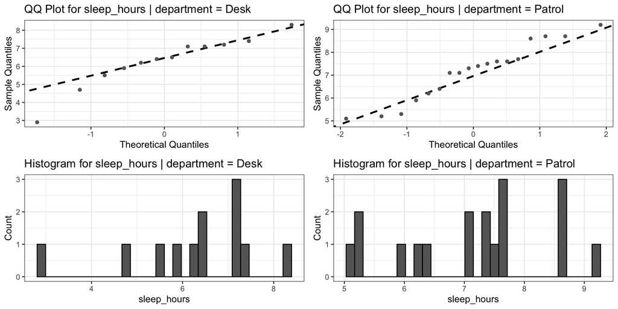

## Example 2

- Let’s check the normality assumption for the side hustle earnings data.

```r
zootopia |> independent_qq(outcome = hustle_earnings,
                           grouping = department)
```

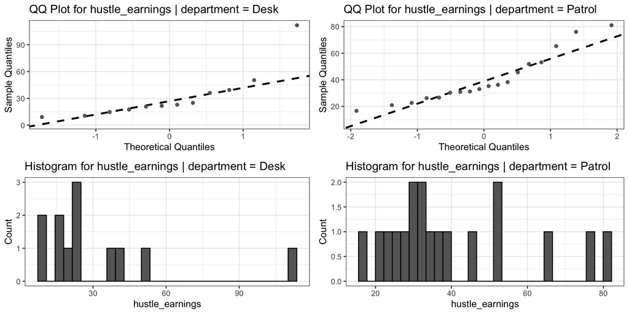

## Confidence Interval for $M_1-M_2$

- The confidence interval is built on every possible pairwise difference between the two groups.
  - We examine the $n_1 \times n_2$ differences between the observations.
    - i.e., We take each observation in Group 1 and subtract each observation in Group 2.
- The median of that pool of differences is the Hodges–Lehmann estimate.
  - It estimates the typical *shift* between the two groups.
- The CI is then found by
  - ranking that entire pool of $n_1 \times n_2$ differences from smallest to largest,
  - then we pick two values from that ranked list as the lower and upper bounds.

## Hypothesis Test for $M_1-M_2$

**Hypotheses**

**Two-Tailed**

$H_0: M_1 - M_2 = M_0$

$H_1: M_1 - M_2 \ne M_0$

**Left-Tailed**

$H_0: M_1 - M_2 \ge M_0$

$H_1: M_1 - M_2 < M_0$

**Right-Tailed**

$H_0: M_1 - M_2 \le M_0$

$H_1: M_1 - M_2 > M_0$

- $M_i$ is the population median for group $i$, and
- $M_0$ is the hypothesized difference between the groups

## Hypothesis Test for $M_1-M_2$

**Test Statistic**

$$T_0 = \sum R_{\text{1}} - \frac{n_1(n_1+1)}{2}$$

- where
  - $\sum R_1$ is the sum of the ranks for the first group
  - $n_1$ is the sample size of the first group

## Statistical Inference on Two Medians (`R`)

- We will use the `independent_medians` function from `library(ssstats)` to perform statistical inference.
- Generic syntax:

```r
dataset_name |> independent_medians(
  outcome = outcome_variable,
  grouping = grouping_variable,
  alternative = "two" | "less" | "greater",
  m = hypothesized_difference,
  alpha = alpha_level
  )
```

**1**

Pipes your dataset into `independent_medians()`.

**2**

`outcome`: the continuous variable you want to compare between the two groups.

**3**

`grouping`: the categorical variable that splits your data into the two groups being compared.

**4**

`alternative`: the direction of the test; default is `two`.

**5**

`m`: the hypothesized difference between the two groups under $H_0$; default is 0.

**6**

`alpha`: the significance level; default is 0.05.

## Example 1

- Then, we will perform a hypothesis test to answer the question.
  - Is there a difference in average (median) nightly sleep between Patrol and Desk officers?
- How do we translate this into hypotheses?
  - $H_0: M_{\text{Patrol}} = M_{\text{Desk}}$
  - $H_1: M_{\text{Patrol}} \ne M_{\text{Desk}}$
- For the `independent_medians()` function, we will set
  - `m = 0`
  - `alternative = "two"`.

## Example 1

```r
zootopia |> independent_medians(outcome = sleep_hours,
                                grouping = department)
```

```
Independent medians

M[Desk] = 6.45
M[Patrol] = 7.35
Hodges-Lehmann estimate of median difference: -0.7

95% CI for M[Desk] − M[Patrol]: (-1.7, 0.1)

Hypotheses:
H₀: M[Desk] − M[Patrol] = 0
H₁: M[Desk] − M[Patrol] ≠ 0
Test statistic: W = 68
p-value: 0.092
Conclusion: Fail to reject the null hypothesis (p = 0.092 ≥ α = 0.050)
```

## Example 1

- **Hypotheses**
  - $H_0: M_{\text{Desk}} = M_{\text{Patrol}}$
  - $H_1: M_{\text{Desk}} \ne M_{\text{Patrol}}$
- **Test Statistic and *p*-Value**
  - $T_0 = 68$
  - $p = 0.092$
- **Rejection Region**
  - Reject $H_0$ if $p < \alpha$; $\alpha = 0.05$
- **Conclusion and Interpretation**
  - Fail to reject $H_0$. There is not sufficient evidence to suggest that median sleep differs between Patrol and Desk officers.

## Example 2

```r
zootopia |> independent_medians(outcome = hustle_earnings,
                              grouping = department, alternative = "less")
```

```
Independent medians

M[Desk] = 22.265
M[Patrol] = 34.17
Hodges-Lehmann estimate of median difference: -11.695

95% CI for M[Desk] − M[Patrol]: (-23.54, 0.7)

Hypotheses:
H₀: M[Desk] − M[Patrol] ≥ 0
H₁: M[Desk] − M[Patrol] < 0
Test statistic: W = 63
p-value: 0.029
Conclusion: Reject the null hypothesis (p = 0.029 < α = 0.050)
```

## Example 2

- **Hypotheses**
  - $H_0: M_{\text{Desk}} \ge M_{\text{Patrol}}$
  - $H_1: M_{\text{Desk}} < M_{\text{Patrol}}$
- **Test Statistic and *p*-Value**
  - $T_0 = 63$
  - $p = 0.029$
- **Rejection Region**
  - Reject $H_0$ if $p < \alpha$; $\alpha = 0.05$
- **Conclusion and Interpretation**
  - Reject $H_0$. There is sufficient evidence to suggest that median side hustle earnings are greater among those on patrol.